# ETC1010 Assignment 1

Group One

## Part 1

```r
library(readxl)
library(tidyverse)
passengers <- read_xls("WebAirport_FY_1986-2017.xls", sheet=3, skip=6)
passengers_long <- passengers %>%
  select (AIRPORT,Year,INBOUND,OUTBOUND,INBOUND__1,OUTBOUND__1)%>%
gather(Type_of_Flight, Count,-AIRPORT,-Year,na.rm = TRUE)%>%
  mutate(Type_of_Flight = sub("INBOUND", "DOMESTIC_IN", Type_of_Flight)) %>%
  mutate(Type_of_Flight = sub("OUTBOUND", "DOMESTIC_OUT", Type_of_Flight))%>%
  mutate(Type_of_Flight = sub("DOMESTIC_IN__1", "INTERNATIONAL_IN", Type_of_Flight)) %>%
  mutate(Type_of_Flight = sub("DOMESTIC_OUT__1", "INTERNATIONAL_OUT", Type_of_Flight))%>%
separate(Type_of_Flight, c("Type", "Bound"))
passengers_long
```

```
## # A tibble: 12,672 x 5
##    AIRPORT         Year    Type     Bound     Count
##    <chr>           <chr>   <chr>    <chr>     <dbl>
##  1 TOTAL AUSTRALIA 1985-86 DOMESTIC IN    14543928.
##  2 TOTAL AUSTRALIA 1986-87 DOMESTIC IN    15001877.
##  3 TOTAL AUSTRALIA 1987-88 DOMESTIC IN    16181355.
##  4 TOTAL AUSTRALIA 1988-89 DOMESTIC IN    16497749.
##  5 TOTAL AUSTRALIA 1989-90 DOMESTIC IN    11861519.
##  6 TOTAL AUSTRALIA 1990-91 DOMESTIC IN    16536767.
##  7 TOTAL AUSTRALIA 1991-92 DOMESTIC IN    20525193.
##  8 TOTAL AUSTRALIA 1992-93 DOMESTIC IN    20923187.
##  9 TOTAL AUSTRALIA 1993-94 DOMESTIC IN    22668912.
## 10 TOTAL AUSTRALIA 1994-95 DOMESTIC IN    25091352.
## # ... with 12,662 more rows
```

## Part 2

### Barchart of type of flight, facetted by year

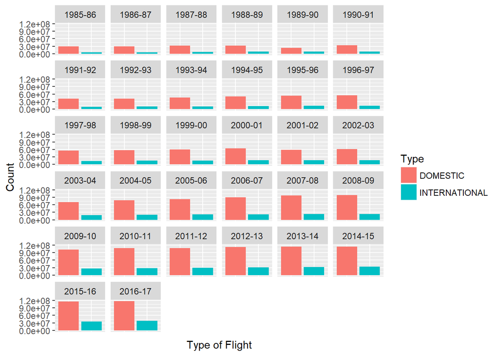

```r
passengers_total = filter(passengers_long, AIRPORT == "TOTAL AUSTRALIA")
ggplot(passengers_total) +
  geom_bar(aes(x = Type, weight = Count, fill = Type)) +
  facet_wrap(~Year) +
  xlab("Type of Flight") +
  ylab("Count") +
  theme(axis.text.x=element_blank(), axis.ticks.x = element_blank())
```

### Interpretation

From the graph we can see that the amount of domestic flight is always higher than that of international flight in Australia. The gap between them was very high in 1985-86, and the gap keeps getting bigger and bigger. it means that the amount of domestic flight is growing at a much higher speed than that of international. We might also say that local australian are more willing to take flight within the coutry, rather than travel internationally. This is further compounded by the fact that international travellers may take multiple flights domestically within the country, but will still just have the 2 international flights (in and outbound). While international flights are growing at slower rate than domestic flights, there is still a relatively large increase overtime. This indicates a general upwards trend in the number of flights. This is due to many factors which can include improving technology allowing more frequent and cheaper flights, a more globalised world encouraging greater travel and so on.

### Scatterplot of domestic inbound vs outbound passengers, facetted by year

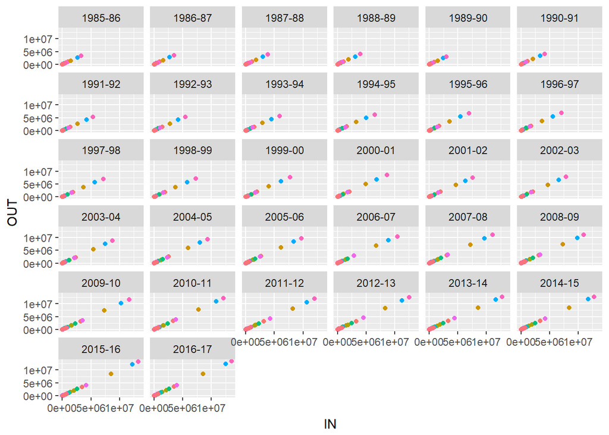

```r
passengers_domestic <- filter(passengers_long, AIRPORT != "TOTAL AUSTRALIA" & Type == "DOMESTIC") %>% spread(Bound, Count)
ggplot(passengers_domestic) +
  geom_point(aes(x = IN, y = OUT, color = AIRPORT), show.legend = FALSE) +
  facet_wrap(~Year)
```

### Interpretation

The first thing of note from this graph is that the number of inbound passengers is typically the same as the number of outbound passengers (as data points are lying on or close to the y = x line). This is an expected result as most people travelling will fly to a new destination (inbound), before flying back home or to another destination (outbound). The only times were a passenger is not inbound and then again outbound is if they are moving permanently, or arrive/depart by method other than flight (e.g. drive). The proportion of these passengers is relatively small, resulting in the almost straight-line data set.

Overtime the number of passengers is generally increasing, resulting in a shift to the right and up. This is more noticeable in the 3 biggest airports, as they are growing far faster than the remaining airports, many of which are rural. While there are too many airports to include the legend, we can see it is the same 3 airports every year that serve the most passengers. BY arranging the airports off number if inbound passengers in 2016-17, as shown below, we can see that these airports in decreasing size are Sydney (Pink), Melbourne (Blue) and Brisbane (Brown). This makes sense as these are the 3 biggest cities in Australia.

```r
#descending order
arrange(filter(passengers_domestic, Year == "2016-17"), desc(IN))
```

```
## # A tibble: 98 x 5
##    AIRPORT    Year    Type            IN       OUT
##    <chr>      <chr>   <chr>        <dbl>     <dbl>
##  1 SYDNEY     2016-17 DOMESTIC 13528670. 13511876.
##  2 MELBOURNE  2016-17 DOMESTIC 12496599. 12431449.
##  3 BRISBANE   2016-17 DOMESTIC  8537777.  8515004.
##  4 PERTH      2016-17 DOMESTIC  3993410.  4036114.
##  5 ADELAIDE   2016-17 DOMESTIC  3526051.  3522386.
##  6 GOLD COAST 2016-17 DOMESTIC  2665163.  2686936.
##  7 CAIRNS     2016-17 DOMESTIC  2122896.  2127229.
##  8 CANBERRA   2016-17 DOMESTIC  1467735.  1463803.
##  9 HOBART     2016-17 DOMESTIC  1216829.  1223963.
## 10 DARWIN     2016-17 DOMESTIC   901972.   906632.
## # ... with 88 more rows
```

### Scatterplot of international inbound vs outbound passengers facetted by year

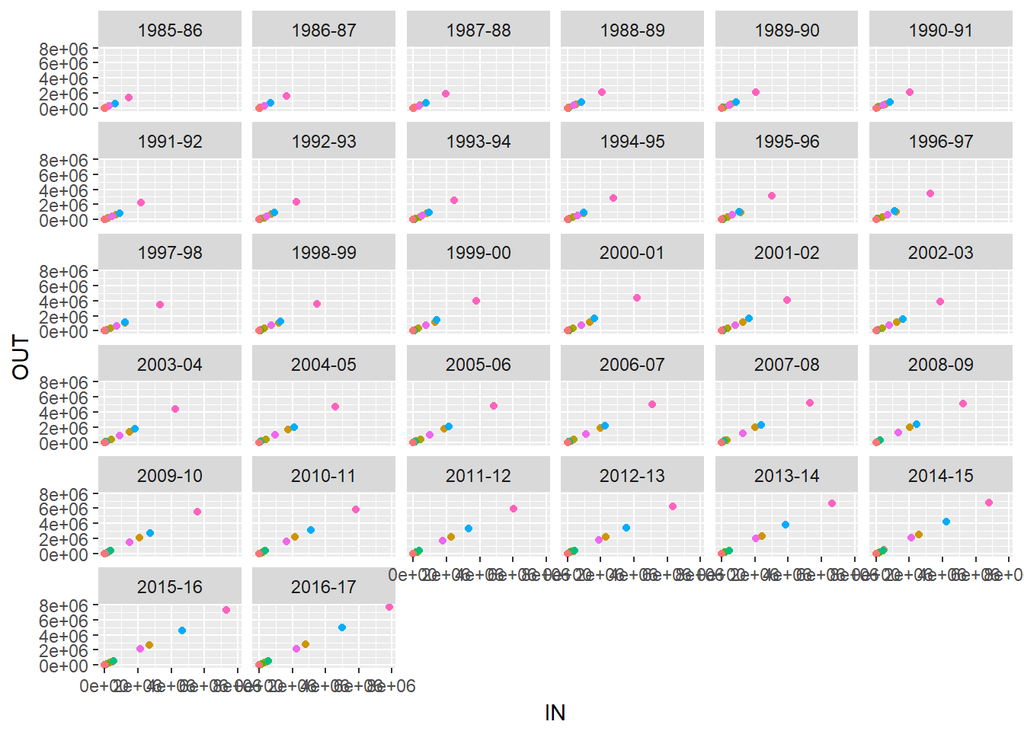

```r
passengers_int <- filter(passengers_long, AIRPORT != "TOTAL AUSTRALIA" & Type == "INTERNATIONAL") %>% spread(Bound, Count)
ggplot(passengers_int) +
  geom_point(aes(x = IN, y = OUT, color = AIRPORT), show.legend = FALSE) +
  facet_wrap(~Year)
```

### Interpretation

Similar to with the domestic flights, there is a relatively strong relationship between Inbound and Outbound passengers. This is for the same reasons, where most passengers would fly into Australia then leave again or vice versa. Only immigrant would change this relationship, however these make up a small portion of passengers. From 1985 until 2017 the number of passengers is increasing, this is in line with the previous graphs’ trends, as flights become more accessible. The other thing of note with international flights is the much smaller number of points than in the domestic flights graph, as not all airports offer international flights. The fewer data points has resulted in greater spread, as the various airports grow at differing rates. Again, we can see Sydney and Melbourne (our 2 biggest cities), have the 2 greatest number of passengers.

## Contributions

All 3 team members contributed equally (1/3 each) to this assignment.

- Alvin
  - Preparing data
  - Finalizing report
- Robert
  - Re-checking the data
  - Making the required plots
- Yingqiu
  - Answering any questions required
  - Interpreting data and graph